# Practical session: population structure with PCA and sNMF

Vitor C. Sousa

March 8, 2018

# Objectives of this practical session

3. Characterize the population structure with individual-based methods
- Principal component analyses (PCA)
- Infer individual ancestry coefficients with sparse Nonlinear Matrix Factorization (sNMF)

TO DISCUSS:  
- Can we infer ancestry coefficients for each individual?  
- What do the detected clusters mean?

## BEFORE STARTING. Install required packages

In this session we will use the following packages:  
+ LEA

## 3. Characterize the population structure with individual-based methods

### 3.1. Principal component analyses (PCA)

> Exercise 1  
> - Perform PCA on the Henn et al (2015) dataset  
> - Plot the pairwise comparisons of the first 4 components  
> - What do these PCs mean? Which ones are the more important?

Follow the R script below to perform the PCA. You will need to understand the output in order to plots the different PCs.

```r
# read the genotype matrix
geno <- as.matrix(read.table("./Henn_et_al_data/Hennetal_genotypeMatrix.geno", header=T, stringsAsFactors = F, na.strings = "NA"))
# check if we read genotype matrix correctly
# str(geno) # matrix with nsites rows and nind columns

# ID of individuals correspond to column names
inds <- colnames(geno)

# Get the index of the individuals from each population
pop.names <- c("San","Mbuti","Mozabite","Pathan","Cambodian","Yakut","Maya")
sample_inds <- list() # list to save the index of individuals belonging to each pop
for(i in 1:length(pop.names)) {
  # use the function which() to get the index
  # of individuals whose initial characters of the name are equal to pop.names
  sample_inds[[i]] <- which(substr(inds, 1, nchar(pop.names[i]))==pop.names[i])
}
# check the result
# str(sample_inds)

# Get a vector with the population for each individual
popinds <- inds # just initiliaze to the individual labels
for(i in 1:length(pop.names)) {
  popinds[sample_inds[[i]]] <- pop.names[i]
}
# check the result
# str(popinds)
```

```r
# load LEA package
library("LEA")

# create tag for filename with results
filename_tag <- "HumanData"

# Need to create the input file (geno SNMF file)
genoSNMF <- geno
# replace missing data by "9"
genoSNMF[is.na(genoSNMF)]=9
# save the file with the genotypes using 9 as missing data
write(t(genoSNMF),file=paste(filename_tag, "_sNMF.geno",sep=""), ncolumns = ncol(genoSNMF), sep="")

# Perform PCA with LEA package
# Create a pcaProject object: pc.
pc <- pca(paste(filename_tag, "_sNMF.geno",sep=""), scale = FALSE, center=TRUE)
```

```
## [1] "*********************************************************"
## [1] " Conversion from the geno format to the lfmm format"
## [1] "*********************************************************"
##
##  - number of detected individuals:   54
##  - number of detected loci:      10000
##
## [1] "******************************"
## [1] " Principal Component Analysis "
## [1] "******************************"
## summary of the options:
##
##         -n (number of individuals)          54
##         -L (number of loci)                 10000
##         -K (number of principal components) 54
##         -x (genotype file)                  C:\Users\Vitor Sousa\Dropbox\UNIVERSITY\courses\EvolutionaryGenomics\EvolGen_2018\Day2\Practical_PopulationStructure\HumanData_sNMF.lfmm
##         -a (eigenvalue file)                C:\Users\Vitor Sousa\Dropbox\UNIVERSITY\courses\EvolutionaryGenomics\EvolGen_2018\Day2\Practical_PopulationStructure\HumanData_sNMF.pca\/HumanData_sNMF.eigenvalues
##         -e (eigenvector file)               C:\Users\Vitor Sousa\Dropbox\UNIVERSITY\courses\EvolutionaryGenomics\EvolGen_2018\Day2\Practical_PopulationStructure\HumanData_sNMF.pca\/HumanData_sNMF.eigenvectors
##         -d (standard deviation file)        C:\Users\Vitor Sousa\Dropbox\UNIVERSITY\courses\EvolutionaryGenomics\EvolGen_2018\Day2\Practical_PopulationStructure\HumanData_sNMF.pca\/HumanData_sNMF.sdev
##         -p (projection file)                C:\Users\Vitor Sousa\Dropbox\UNIVERSITY\courses\EvolutionaryGenomics\EvolGen_2018\Day2\Practical_PopulationStructure\HumanData_sNMF.pca\/HumanData_sNMF.projections
##         -c data centered
```

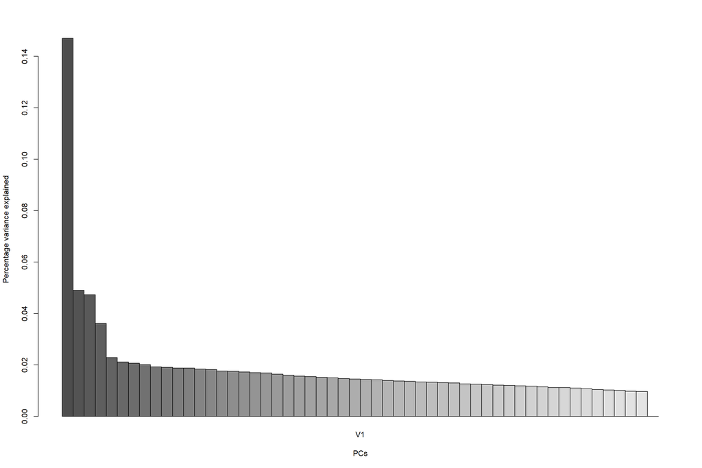

```r
#######################
# Display Information #
#######################

# Display information about the analysis.
#show(pc)

# Summarize the analysis.
#summary(pc)

#####################
# Graphical outputs #
#####################
library(RColorBrewer)
mycols <- brewer.pal("Paired", n=length(pop.names))

# get the explained percentage
perc_exp <- pc$eigenvalues/sum(pc$eigenvalues, na.rm=T)
barplot(perc_exp, ylab="Percentage variance explained", xlab="PCs", beside=T)
```

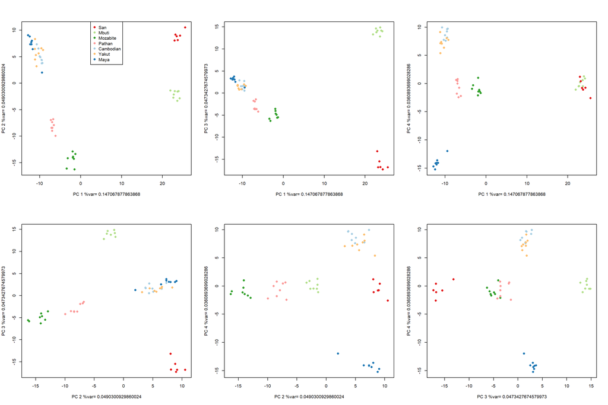

```r
# Look at the resulting eigenvectors
indcolor <- as.numeric(factor(popinds)) # set the color for each individual
# Plot the first PCs
par(mfrow=c(2,3))
for(i in 1:3) {
  for(j in (i+1):4) {
    plot(pc$projections[,i],pc$projections[,j], col=mycols[indcolor], pch=16, xlab=paste("PC", i, "%var=", perc_exp[i]), ylab=paste("PC", j, "%var=", perc_exp[j]),)
    if(i==1 & j==2) {
    legend("top", pop.names, col=mycols[factor(pop.names)], pch=16)
    }

  }
}
```

```r
#############################
# Perform Tracy-Widom tests #
#############################

# Perfom Tracy-Widom tests on all eigenvalues.
# Create file: genotypes.tracyWidom - tracy-widom test information,
#          in the directory genotypes.pca/.
#tw = tracy.widom(pc)

# BUG I FOUND: Might need to check the output file from PCA, to remove scientific notation values... Open the file and change it in a text editor.

# Display the p-values for the Tracy-Widom tests.
#par(mfrow=c(1,1))
#plot(log10(tw$pvalues))

# How many PCs are significant?
```

### 3.2. Infer individual ancestry coefficients with sparse Nonlinear Matrix Factorization (sNMF)

> Exercise 2  
> - Use sNMF to analyse the Henn et al (2015) data  
> - What is the best K to explain the data?  
> - How many populations do we have in this dataset?  
> - Can you detect any migrant individual?

Follow the R command lines below to perform the sNMF analyses.

```r
# load LEA package
library("LEA")

# Need to create the input file (geno SNMF file)
genoSNMF <- geno
# replace missing data by "9"
genoSNMF[is.na(genoSNMF)]=9
# save the file
write(t(genoSNMF),file=paste(filename_tag, "_sNMF.geno",sep=""), ncolumns = ncol(genoSNMF), sep="")
# run sNMF from K values 1 up to 5
obj.at = snmf(paste(filename_tag, "_sNMF.geno",sep=""), K=1:5, ploidy=2, entropy=T, CPU=3, project="new", repetitions=1)

# look at what is in obj.at
str(obj.at)

# Find the index of the end of each population
npops <- length(pop.names)
indexpop <- numeric(npops)
for(i in 1:npops){
  indexpop[i] <- max(sample_inds[[i]])
}

pdf("AdmixtureProportions.pdf", width=10, height=6)
# Plot the results for each K value and the cross-entropy
par(mfrow=c(1,1))
for(k in 2:5) {
  mycols=brewer.pal(k, "Paired")
  # the Q() function gets the ancestry coefficients for each K value
  bp=barplot(t(Q(obj.at, K=k)), horiz = F, beside = F, col = mycols, space=0.01, border=NA)
  # add lines dividing the populations
  abline(v=indexpop, col=1, lwd=2)
  # add the population names below each area
  axis(side=1, at=indexpop-2, labels=pop.names)
}
# Plot the cross-entropy
par(mfrow=c(1,1))
plot(obj.at)
dev.off()

# What is the best K-value?
```

> TO DISCUSS  
> - Do the PCA and Ancestry proportions analysis indicate the same population structure?  
> - Based on these results, what is the human population structure?  
> - What are the likely demographic events that lead to this structure?  
> - Is there any cryptic population structure within each sampled location?  
> - Is there evidence of hybrid (admixed) individuals between different populations?  
> - Is there evidence of shared ancestry? That is, two populations that descend from the same ancestral population?